# Module 1

David Blumenstiel

1/30/2021

**Principles of Data Visualization and Introduction to ggplot2**

I have provided you with data about the 5,000 fastest growing companies in the US, as compiled by Inc. magazine. lets read this in:

```r
inc <- read.csv("https://raw.githubusercontent.com/charleyferrari/CUNY_DATA_608/master/module1/Data/inc5000_data.csv", header= TRUE)
```

And lets preview this data:

```r
head(inc)
```

```
##   Rank                         Name Growth_Rate   Revenue
## 1    1                         Fuhu      421.48 1.179e+08
## 2    2        FederalConference.com      248.31 4.960e+07
## 3    3                The HCI Group      245.45 2.550e+07
## 4    4                      Bridger      233.08 1.900e+09
## 5    5                       DataXu      213.37 8.700e+07
## 6    6 MileStone Community Builders      179.38 4.570e+07
##                       Industry Employees         City State
## 1 Consumer Products & Services       104   El Segundo    CA
## 2          Government Services        51     Dumfries    VA
## 3                       Health       132 Jacksonville    FL
## 4                       Energy        50      Addison    TX
## 5      Advertising & Marketing       220       Boston    MA
## 6                  Real Estate        63       Austin    TX
```

```r
summary(inc)
```

```
##       Rank                          Name       Growth_Rate
##  Min.   :   1   (Add)ventures         :   1   Min.   :  0.340
##  1st Qu.:1252   @Properties           :   1   1st Qu.:  0.770
##  Median :2502   1-Stop Translation USA:   1   Median :  1.420
##  Mean   :2502   110 Consulting        :   1   Mean   :  4.612
##  3rd Qu.:3751   11thStreetCoffee.com  :   1   3rd Qu.:  3.290
##  Max.   :5000   123 Exteriors         :   1   Max.   :421.480
##                 (Other)               :4995
##     Revenue                                  Industry      Employees
##  Min.   :2.000e+06   IT Services                 : 733   Min.   :    1.0
##  1st Qu.:5.100e+06   Business Products & Services: 482   1st Qu.:   25.0
##  Median :1.090e+07   Advertising & Marketing     : 471   Median :   53.0
##  Mean   :4.822e+07   Health                      : 355   Mean   :  232.7
##  3rd Qu.:2.860e+07   Software                    : 342   3rd Qu.:  132.0
##  Max.   :1.010e+10   Financial Services          : 260   Max.   :66803.0
##                      (Other)                     :2358   NA's   :12
##             City          State
##  New York     : 160   CA     : 701
##  Chicago      :  90   TX     : 387
##  Austin       :  88   NY     : 311
##  Houston      :  76   VA     : 283
##  San Francisco:  75   FL     : 282
##  Atlanta      :  74   IL     : 273
##  (Other)      :4438   (Other):2764
```

Think a bit on what these summaries mean. Use the space below to add some more relevant non-visual exploratory information you think helps you understand this data:

We’ll start with this:

```r
library(psych)
describe(inc)  # A nice little function that gives you a bit more than summary()
```

```
##             vars    n        mean           sd    median     trimmed
## Rank           1 5001     2501.64      1443.51 2.502e+03     2501.73
## Name*          2 5001     2501.00      1443.81 2.501e+03     2501.00
## Growth_Rate    3 5001        4.61        14.12 1.420e+00        2.14
## Revenue        4 5001 48222535.49 240542281.14 1.090e+07 17334966.26
## Industry*      5 5001       12.10         7.33 1.300e+01       12.05
## Employees      6 4989      232.72      1353.13 5.300e+01       81.78
## City*          7 5001      732.00       441.12 7.610e+02      731.74
## State*         8 5001       24.80        15.64 2.300e+01       24.44
##                     mad     min        max      range  skew kurtosis         se
## Rank            1853.25 1.0e+00 5.0000e+03 4.9990e+03  0.00    -1.20      20.41
## Name*           1853.25 1.0e+00 5.0010e+03 5.0000e+03  0.00    -1.20      20.42
## Growth_Rate        1.22 3.4e-01 4.2148e+02 4.2114e+02 12.55   242.34       0.20
## Revenue     10674720.00 2.0e+06 1.0100e+10 1.0098e+10 22.17   722.66 3401441.44
## Industry*          8.90 1.0e+00 2.5000e+01 2.4000e+01 -0.10    -1.18       0.10
## Employees         53.37 1.0e+00 6.6803e+04 6.6802e+04 29.81  1268.67      19.16
## City*            604.90 1.0e+00 1.5190e+03 1.5180e+03 -0.04    -1.26       6.24
## State*            19.27 1.0e+00 5.2000e+01 5.1000e+01  0.12    -1.46       0.22
```

Lot’s of information here, not all of which is relevant (categorical data isn’t going to have a mean for example), but includes some basics like n and standard deviations, and some more niche stuff like skew and kurtosis.

Another pretty basic but helpful thing to do:

```r
print(dim(inc))
```

```
## [1] 5001    8
```

```r
print(sapply(inc, class))
```

```
##        Rank        Name Growth_Rate     Revenue    Industry   Employees
##   "integer"    "factor"   "numeric"   "numeric"    "factor"   "integer"
##        City       State
##    "factor"    "factor"
```

You technically get this stuff by printing the head and looking at the data-viewer (top right), but it’s helpful to know what the data ‘looks like’

## Question 1

Create a graph that shows the distribution of companies in the data-set by State (ie how many are in each state). There are a lot of States, so consider which axis you should use. This visualization is ultimately going to be consumed on a ‘portrait’ oriented screen (ie taller than wide), which should further guide your layout choices.

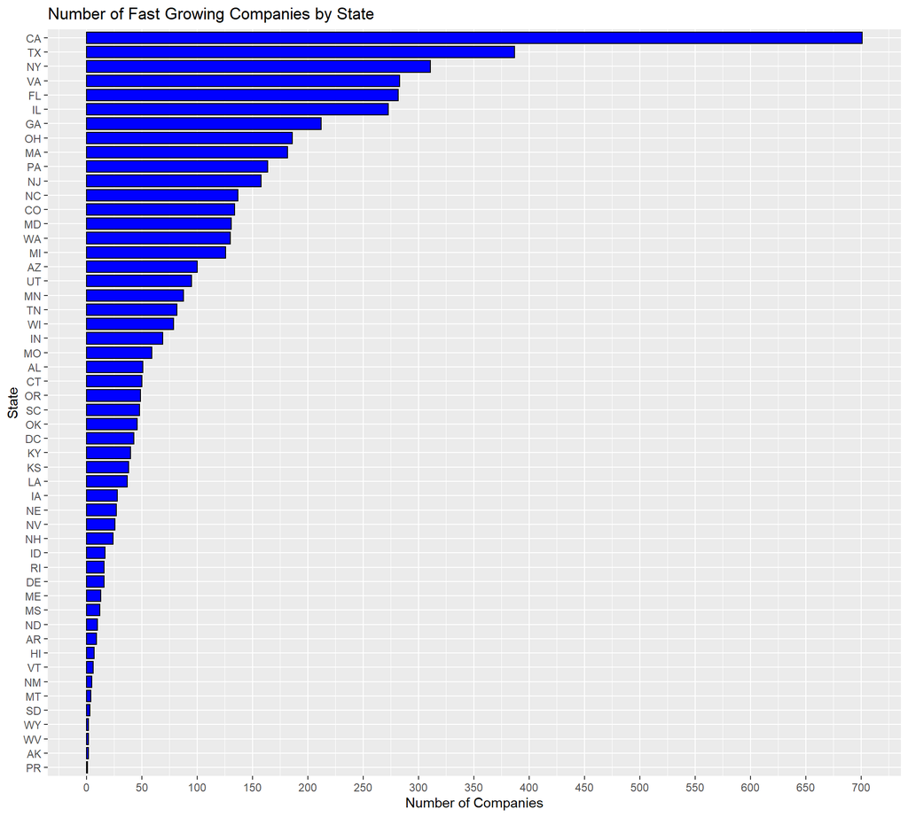

```r
library(ggplot2)
library(dplyr)
State_counts <- inc %>%          #Counts the number of states for each state
  group_by(State) %>%
  count()




ggplot(State_counts, aes(x = reorder(State, n), y = n)) +  #tells it to look at the 'State' variable in the 'inc dataset, orders it from highest to lowest
  geom_bar(stat = 'identity', width=0.8, fill = 'blue', color = 'black') + #Makes a barplot, also adds color so it's less dull
  coord_flip() + #Inverts it so the states are listed on the y axis, which I like to do when there are lots of categories
  ggtitle('Number of Fast Growing Companies by State') +  #A title
  xlab("State") +    #Things got flipped, so this will show on the actual y axis
  ylab("Number of Companies") +
  scale_y_continuous(breaks = seq(0, 750, by = 50)) #Adds a few more tickmarks
```

A pretty basic bar-plot. Counting n on the x axis makes categorical labeling easier when there are lots of categories like there are here. An alternative to that would be to rotate the labels, but when they’re short abbreviations like this it doesn’t make as much sense.

## Question 2

Lets dig in on the state with the 3rd most companies in the data set. Imagine you work for the state and are interested in how many people are employed by companies in different industries. Create a plot that shows the average and/or median employment by industry for companies in this state (only use cases with full data, use R’s `complete.cases()` function.) In addition to this, your graph should show how variable the ranges are, and you should deal with outliers.

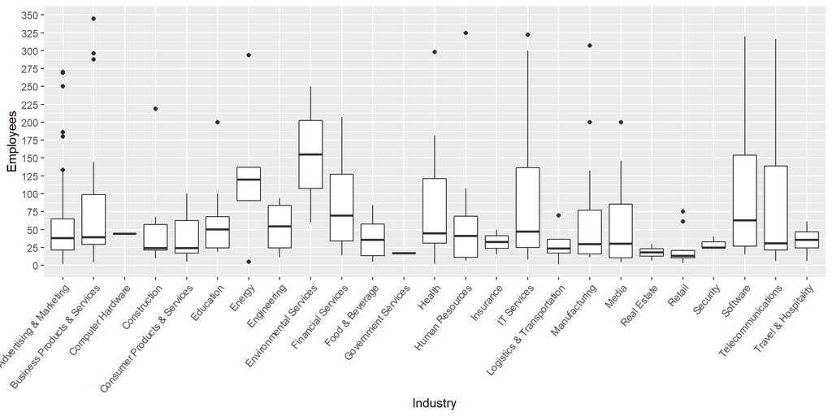

```r
#First we'll sepeate NY, the one with the third most companies in the dataset
NY <- inc[complete.cases(inc),] %>% #Removes incomplete observations
  filter(State == 'NY') %>%  #Only NY.  Were I doing this with a non-static dataset, I would select this programatticaly
  select(Industry, Employees) #We just need the industry and employees for each company

#Deals with outliers by using data within a certain multiple of the IQR from the third quartile
#Note: this is taking the whole dataset into account, and not doing it per industry (which would or would not be optimal)
Outlier_coef = 3  #Choose 3 for this because it looks good
NY <- NY[NY$Employees < quantile(NY$Employees, 0.75) + IQR(NY$Employees)*Outlier_coef,]



#Makes box and whisker plot
ggplot(NY, aes(x = Industry, y = Employees)) +
  geom_boxplot()+
  scale_x_discrete(guide = guide_axis(angle = 50)) + #Founds this line here: https://stackoverflow.com/questions/1330989/rotating-and-spacing-axis-labels-in-ggplot2
  scale_y_continuous(breaks = seq(0, 400, by = 25))
```

Above is a basic box and whisker plot, with an outlier cutoff at 3*IQR (for the data-set as a whole). I like box and whisker for cases like this because it gives a decent and quick visualization of where the data is and how variable it is. The outlier cutoff here is a bit trickier: I went with about twice the usual to preserve some of the data. Including all outliers obscures the plot.

## Question 3

Now imagine you work for an investor and want to see which industries generate the most revenue per employee. Create a chart that makes this information clear. Once again, the distribution per industry should be shown.

(Assuming this is for all states again)

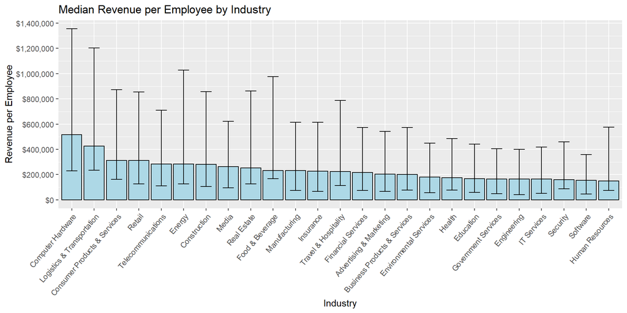

```r
IRE <- inc[complete.cases(inc),] %>% #Gets rid of those pesky Na's
  mutate(rev_per_emp = Revenue/Employees) %>% #Makes a new variable of revenue per employee
  select(Industry, rev_per_emp) %>%  #Subsets the variables we want
  group_by(Industry) %>% #Groups by indsutry
  summarize(Median = median(rev_per_emp), n = n(), Q1 = quantile(rev_per_emp, 0.25), Q3 = quantile(rev_per_emp, 0.75)) # gives us stats we want


ggplot(IRE, aes(x = reorder(Industry, -Median), y = Median)) +  #Iniates plot.  Orders it by decending order
  geom_bar(stat = 'identity', col = "black", fill ="lightblue") + #Makes it a barplot
  geom_errorbar(aes(ymin = Median - Q1, ymax = Median + Q3), width = 0.5) + #Techically not 'error'; this adds the IQR
  scale_x_discrete(guide = guide_axis(angle = 50)) +   #Angles X axis text so it's readable
  scale_y_continuous(labels=scales::dollar_format(), breaks = seq(0, 1e7, by = 2e5)) + #Adds scale formatting.  https://datavizpyr.com/dollar-format-for-axis-labels-with-ggplot2/
  ylab("Revenue per Employee") +   #Labels
  xlab('Industry') +
  ggtitle("Median Revenue per Employee by Industry")
```

I went with a bar-plot here because while they may not get quite as much information across as a box-plot, it’s a bit easier to read and still gives you a good sense of variability if you use the ‘error’ bars .